# Session 5 Assignment

## Google Analytics with R

### startup/ initialization

```r
library(dplyr, warn.conflicts = FALSE)
options(dplyr.summarise.inform = FALSE) # Suppress summarise info

suppressPackageStartupMessages(library(tidyverse)) # suppress startup message
```

### Read GA data file

Includes sessions, users, bounces for the last 30 days, which was saved a csv file

```
## 'data.frame':    720 obs. of  6 variables:
##  $ date     : Factor w/ 30 levels "2020-08-28","2020-08-29",..: 1 1 1 1 1 1 1 1 1 1 ...
##  $ dayOfWeek: int  5 5 5 5 5 5 5 5 5 5 ...
##  $ hour     : int  0 1 2 3 4 5 6 7 8 9 ...
##  $ sessions : int  0 0 0 0 0 0 0 0 0 0 ...
##  $ users    : int  0 0 0 0 0 0 0 0 0 0 ...
##  $ bounces  : int  0 0 0 0 0 0 0 0 0 0 ...
```

### Convert **date** factor to date. Convert **dayOfWeek** from int to factor

```
## 'data.frame':    720 obs. of  6 variables:
##  $ date     : Date, format: "2020-08-28" "2020-08-28" ...
##  $ dayOfWeek: Factor w/ 7 levels "0","1","2","3",..: 6 6 6 6 6 6 6 6 6 6 ...
##  $ hour     : int  0 1 2 3 4 5 6 7 8 9 ...
##  $ sessions : int  0 0 0 0 0 0 0 0 0 0 ...
##  $ users    : int  0 0 0 0 0 0 0 0 0 0 ...
##  $ bounces  : int  0 0 0 0 0 0 0 0 0 0 ...
```

### Show top and bottom records

```
##         date dayOfWeek hour sessions users bounces
## 1 2020-08-28         5    0        0     0       0
## 2 2020-08-28         5    1        0     0       0
## 3 2020-08-28         5    2        0     0       0
## 4 2020-08-28         5    3        0     0       0
## 5 2020-08-28         5    4        0     0       0
## 6 2020-08-28         5    5        0     0       0
```

```
##           date dayOfWeek hour sessions users bounces
## 715 2020-09-26         6   18        0     0       0
## 716 2020-09-26         6   19        0     0       0
## 717 2020-09-26         6   20        0     0       0
## 718 2020-09-26         6   21        0     0       0
## 719 2020-09-26         6   22        0     0       0
## 720 2020-09-26         6   23        0     0       0
```

### Show statistic Summary

- Describe your observations in words.

```
##       date               sessions           users            bounces
##  Min.   :2020-08-28   Min.   :0.00000   Min.   :0.00000   Min.   :0.0000
##  1st Qu.:2020-09-04   1st Qu.:0.00000   1st Qu.:0.00000   1st Qu.:0.0000
##  Median :2020-09-11   Median :0.00000   Median :0.00000   Median :0.0000
##  Mean   :2020-09-11   Mean   :0.01667   Mean   :0.01806   Mean   :0.0125
##  3rd Qu.:2020-09-19   3rd Qu.:0.00000   3rd Qu.:0.00000   3rd Qu.:0.0000
##  Max.   :2020-09-26   Max.   :3.00000   Max.   :3.00000   Max.   :2.0000
```

## create a new dataframe called *cum_sesson_totals*, with session totals by date

```
## # A tibble: 30 x 2
##    date       total_sessions
##    <date>              <int>
##  1 2020-08-28              0
##  2 2020-08-29              0
##  3 2020-08-30              0
##  4 2020-08-31              0
##  5 2020-09-01              0
##  6 2020-09-02              0
##  7 2020-09-03              0
##  8 2020-09-04              0
##  9 2020-09-05              0
## 10 2020-09-06              6
## # … with 20 more rows
```

## Sessions Overview

Use **cum_sesson_totals** to answer the following questions *

1. How many days had 0 sessions? Which days?
2. How many days with sessions?
- Which days?
- Create a contingency table showing the session counts by date

### How many days with sessions (eg: days with at least 1 session)?

We’re trying to capture the information available from GA. Here’s an overview of session activity over the last 30 days. The image below was exported from GA and displayed using R’s imager package

- https://cran.r-project.org/web/packages/imager/vignettes/gettingstarted.html
- https://dahtah.github.io/imager/imager.html

### Informational only (don’t have to do this)

```r
#install.packages('imager')
library(imager)

img <- load.image("SessionsOverview.png")
dim(img)
```

```
## [1] 1020  924    1    4
```

[figure not shown]

```r
plot(img)
```

### How many days had 0 sessions? Which days? (use *cum_sesson_totals*)

```
## [1] 24
```

```
## # A tibble: 24 x 2
##    date       total_sessions
##    <date>              <int>
##  1 2020-08-28              0
##  2 2020-08-29              0
##  3 2020-08-30              0
##  4 2020-08-31              0
##  5 2020-09-01              0
##  6 2020-09-02              0
##  7 2020-09-03              0
##  8 2020-09-04              0
##  9 2020-09-05              0
## 10 2020-09-07              0
## # … with 14 more rows
```

### How many days with 1 or more sessions? Which days? (use *cum_sesson_totals*)

```
## [1] 6
```

```
## # A tibble: 6 x 2
##   date       total_sessions
##   <date>              <int>
## 1 2020-09-06              6
## 2 2020-09-08              1
## 3 2020-09-19              2
## 4 2020-09-23              1
## 5 2020-09-24              1
## 6 2020-09-25              1
```

### contingency table with total sessions by date (for dates with 1 or more sessions)

```
##             total_sessions
## date         1 2 6 Sum
##   2020-09-06 0 0 1   1
##   2020-09-08 1 0 0   1
##   2020-09-19 0 1 0   1
##   2020-09-23 1 0 0   1
##   2020-09-24 1 0 0   1
##   2020-09-25 1 0 0   1
##   Sum        4 1 1   6
```

In my case, I have a total of 12 sessions spanning 9/6 - 9/25

### Informational only (don’t need to include)

```r
# Look at days with 1 or more sessions

# summarize to show the *number of sessions* by date and hour-of-day.
df = ga_datadf %>%
  subset(sessions > 0) %>%
  group_by(date, hour)  %>%
  summarize(sessions)

df
```

```
## # A tibble: 9 x 3
## # Groups:   date [6]
##   date        hour sessions
##   <date>     <int>    <int>
## 1 2020-09-06    14        3
## 2 2020-09-06    15        1
## 3 2020-09-06    16        1
## 4 2020-09-06    17        1
## 5 2020-09-08    19        1
## 6 2020-09-19    16        2
## 7 2020-09-23    13        1
## 8 2020-09-24    16        1
## 9 2020-09-25    23        1
```

```r
# contingency table that shows the days that have at least 1 session
addmargins(with(df, table(date, sessions, dnn = c('date', 'sessions'))))
```

```
##             sessions
## date         1 2 3 Sum
##   2020-09-06 3 0 1   4
##   2020-09-08 1 0 0   1
##   2020-09-19 0 1 0   1
##   2020-09-23 1 0 0   1
##   2020-09-24 1 0 0   1
##   2020-09-25 1 0 0   1
##   Sum        7 1 1   9
```

```r
# filter by session on 9/6 to confirm that 9/16 has 6 sessions
ga_datadf  %>%
  filter(date=='2020-09-06' & sessions > 0) %>%
  summarize(date, hour, sessions)
```

```
##         date hour sessions
## 1 2020-09-06   14        3
## 2 2020-09-06   15        1
## 3 2020-09-06   16        1
## 4 2020-09-06   17        1
```

**Explanation**

- 9/6 has a total of 6 sessions. (3) 1 sessions and (1) 3 sessions. This can be confirmed by looking at the Audience Overview in GA and filtering by specific date
- 9/19 has (2) sessions
- all other dates have just (1) sessions each.
- Total number of sessions for the last 30 days is is 12
- Filter by session on 9/6 to confirm that 9/16 has 6 sessions

## Visualizations

1. Create a time series (eg: line chart) with sessions by day
2. Create a scatter plot with a trend line that shows sessions over time

### Create a time series (eg: line chart) with sessions by day (use *cum_sesson_totals* )

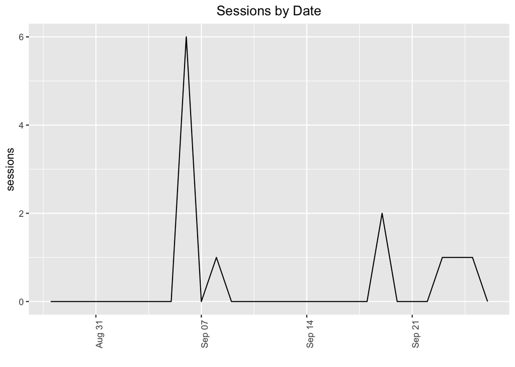

### Create a scatter plot with a trend line showing sessions over time (use *cum_sesson_totals*)

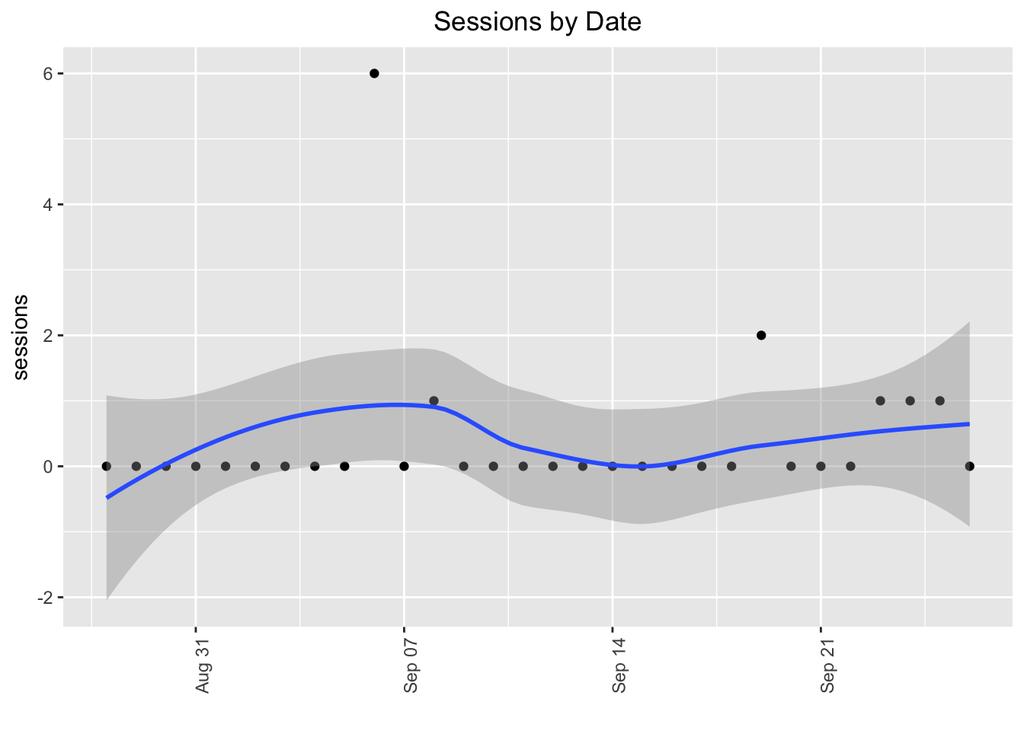

### create a new dataframe called *cum_dayofweek_totals*, with session totals by date and dayOfWeek

```
## # A tibble: 30 x 3
## # Groups:   date [30]
##    date       dayOfWeek total_sessions
##    <date>     <fct>              <int>
##  1 2020-08-28 5                      0
##  2 2020-08-29 6                      0
##  3 2020-08-30 0                      0
##  4 2020-08-31 1                      0
##  5 2020-09-01 2                      0
##  6 2020-09-02 3                      0
##  7 2020-09-03 4                      0
##  8 2020-09-04 5                      0
##  9 2020-09-05 6                      0
## 10 2020-09-06 0                      6
## # … with 20 more rows
```

### Create boxplots showing the number of sessions by day of week (use *cum_dayofweek_totals*)

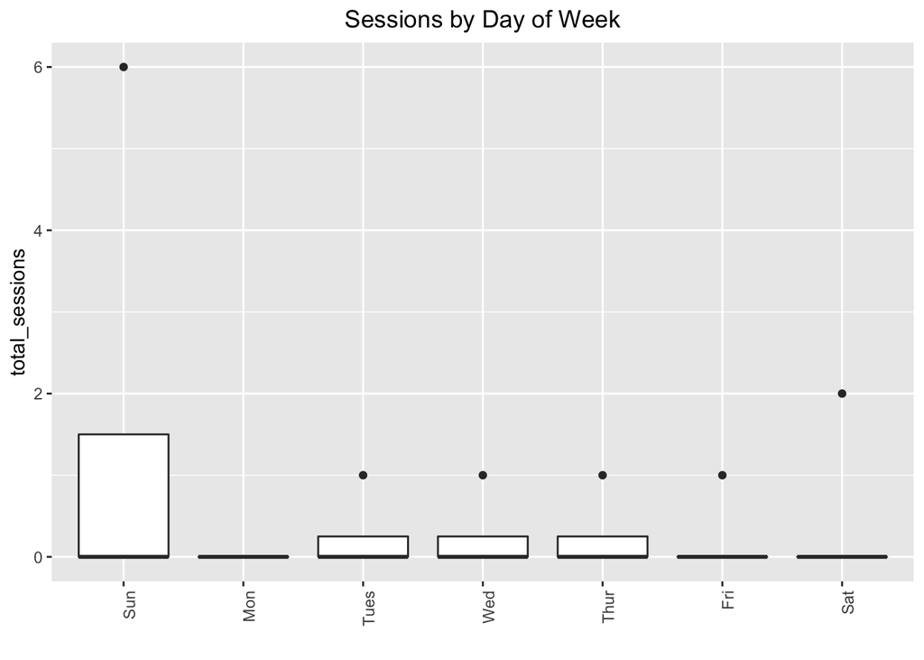

### create a new dataframe called *cum_users_totals*, with user totals by hour and dayOfWeek

```
## # A tibble: 177 x 4
## # Groups:   hour, dayOfWeek [168]
##     hour dayOfWeek users total_users
##    <int> <fct>     <int>       <int>
##  1     0 0             0           0
##  2     0 1             0           0
##  3     0 2             0           0
##  4     0 3             0           0
##  5     0 4             0           0
##  6     0 5             0           0
##  7     0 6             0           0
##  8     1 0             0           0
##  9     1 1             0           0
## 10     1 2             0           0
## # … with 167 more rows
```

### Create heat map plot that shows users by time of day (use *cum_users_totals*)

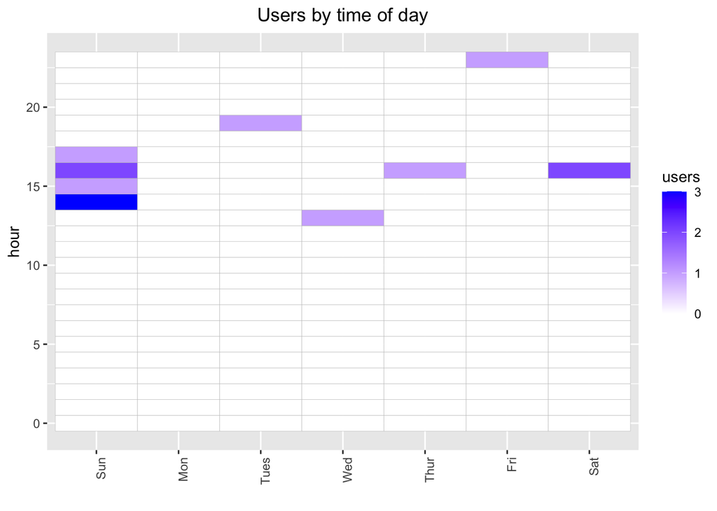